# First Blog

homework 1

DACSS 601

cynthia hester

DACSS 601 HomeWork 1

Cynthia Hester  
09/27/2021

**Introduction**

Hey everyone, my name is Cynthia and this is my first blog post. Whew!! I am a first year MS student in the DACSS program. I have a BS in Human Computer Interaction (HCI) with a minor in Information Technology from UMass-Amherst. I am originally from Port-of Spain, Trinidad. My hobbies include hiking, yoga,cycling, travel and reading.

**Cool stuff *R* can do**

I am going to import data from the Air Passengers data set which is included in R. It is comprised of data from the monthly totals of international airline passengers, 1949 to 1960. I am going visually express the data on a histogram plot which is a strength of R.

First, we are going to look at the first few rows of the Air Passengers argument using the *head function* in R which displays the first few rows of an argument. This is useful so the entire data set does not need be displayed.

```r
head(AirPassengers)
```

```
[1] 112 118 132 129 121 135
```

Next, to get an idea of what is at the end of the Air Passengers data set we are going to use the *tail function* which as the name implies displays what is at the end of the data set.

```r
tail(AirPassengers)
```

```
[1] 622 606 508 461 390 432
```

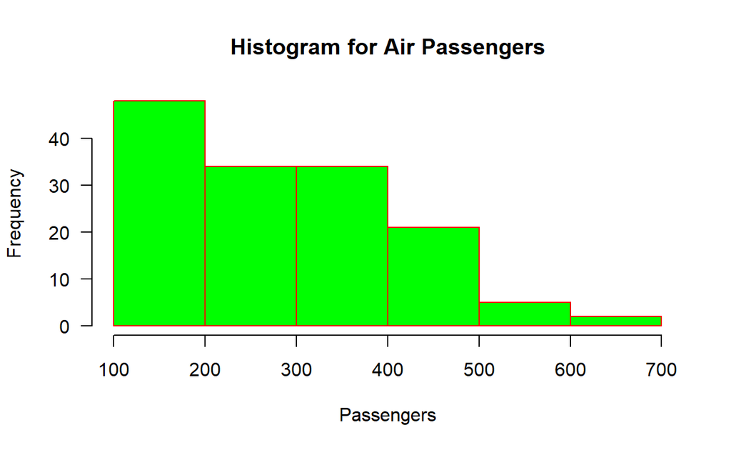

```r
hist(AirPassengers,
     main="Histogram for Air Passengers",
     xlab="Passengers",
     border="red",
     col="green",
     xlim=c(100,700),
     las=1,
     breaks=5)
```